# Práctica: detección de fraude mediante métodos de ensembles

ESTUDIANTES: `SAID DANIEL HUARITA MOLLO`

[figure not shown]

En esta práctica vamos a utilizar todos los conocimientos adquiridos en los ejercicios anteriores, con el objetivo de construir un detector automático de fraude en pagos con tarjeta.

## Instrucciones

A lo largo del notebook encontrarás celdas que debes rellenar con tu propio código. Sigue las instrucciones del notebook y presta atención a los siguientes iconos:

Deberás resolver el ejercicio escribiendo tu propio código o respuesta en la celda inmediatamente inferior. **La nota máxima que puede obtenerse con esta clase de ejercicios es de 7 sobre 10.**

Esto es una pista u observación de utilidad que puede ayudarte a resolver el ejercicio. Presta atención a estas pistas para comprender el ejercicio en mayor profundidad.

Este es un ejercicio avanzado que te puede ayudar a profundizar en el tema, y a conseguir una calificación más alta. **Resolviendo esta clase de ejercicios puedes llegar conseguir hasta 3 puntos sobre 10.** ¡Buena suerte!

Para evitar problemas con imports o incompatibilidades se recomienda ejecutar este notebook en uno de los [entornos de Ensembles recomendados](https://github.com/albarji/teaching-environments-ensembles).

El siguiente código mostrará todas las gráficas en el propio notebook en lugar de generar una nueva ventana.

```python
# Visualizacion
import matplotlib.pyplot as plt
from sklearn.tree import plot_tree
import plotnine as p9

# Manipulacion de datos
import pandas as pd
import numpy as np
from sklearn.preprocessing import OneHotEncoder
from sklearn.model_selection import train_test_split

# Procesamiento de texto
import re

# Modelado
from sklearn.ensemble import IsolationForest
from sklearn.tree import DecisionTreeClassifier
from sklearn.ensemble import RandomForestClassifier
from sklearn.ensemble import ExtraTreesClassifier
from sklearn.ensemble import AdaBoostClassifier
from sklearn.ensemble import GradientBoostingClassifier
from sklearn.ensemble import HistGradientBoostingClassifier
from catboost import CatBoostClassifier
from sklearn.ensemble import VotingClassifier

# Evaluacion y comparación de modelos
from sklearn.metrics import roc_auc_score, roc_curve
from sklearn.model_selection import GridSearchCV
from sklearn.model_selection import RandomizedSearchCV
from sklearn.metrics import RocCurveDisplay
from sklearn.utils.class_weight import compute_sample_weight
```

## Carga y preparación de datos

Para este problema usaremos una versión reducida de los datos disponibles en la competición de Kaggle [IEEE-CIS Fraud Detection](https://www.kaggle.com/c/ieee-fraud-detection/data). Los datos a emplear están incluidos en la carpeta *data*, con ficheros separados para entrenamiento y test. Cada fichero incluye una gran cantidad de variables explicativas sobre la naturaleza de la operación con tarjeta realizada: puede encontrarse información sobre la naturaleza de estas variables en las [discusiones de la competición](https://www.kaggle.com/c/ieee-fraud-detection/discussion/101203). La variable objetivo es `isFraud`, la cual toma el valor 1 para operaciones fraudulentas.

Carga los datos de entrenamiento y test en dos Pandas DataFrames con nombres **train** y **test**, respectivamente.

```python
train = pd.read_csv('../data/train.csv',sep=',',index_col=0)
test = pd.read_csv('../data/test.csv',sep=',', index_col=0)
```

Los datos a utilizar presentan algunas problemáticas que debes resolver antes de pasar a la construcción de modelos:

- Valores de variables expresados como strings. scikit-learn no acepta variables expresadas de esta forma.
- Valores faltantes en muchas variables. Aunque varios modelos de scikit-learn pueden trabajar con valores faltantes sin problemas, otros modelos fallarán al encontrarlos.

Aplica las transformaciones que creas necesarias para tener los datos listos para el modelado. Ten en cuenta que cualquier proceso realizado debe aplicarse tanto a los datos de train como a los de test.

Revisamos las dimensiones de los datasets

```python
print("Dimensiones del dataset de entrenamiento:",train.shape)
print("Dimensiones del dataset de prueba:",test.shape)
```

```
Dimensiones del dataset de entrenamiento: (60000, 394)
Dimensiones del dataset de prueba: (60000, 394)
```

Al tener tantas variables(394) utilizaremos la descripción del dataset de Kaggle, para abordar el problema de una manera adecuada.

- TransactionID: Identificador único de cada transacción.
- isFraud: Indicador de fraude.
- TransactionDT: Delta de tiempo dado una fecha y hora en especifico, (no es timestamp).
- TransactionAMT: Monto de la transacción en dolares americanos (USD).
- ProductCD: Código de producto, producto para cada transacción.
- card1 - card6: Información sobre el pago con tarjeta, tipo de tarjeta, categoría de la tarjeta, banco emisor, país, etc.
- addr: Domicilio del comprador, región y país de facturación.
- dist: Diferentes distancias, las columnas están renombradas para no revelar información sensible.
- P_ and (R__) emaildomain: Dominio de e-mail para comprador y quien recibe la compra.
- C1-C14: Contadores, como la cantidad de direcciones asociadas a la tarjeta de pago, etc.
- D1-D15: Diferencias de tiempo en días, entre ultima compra u otros, etc.
- M1-M9: Coincidencias, como nombres en tarjetas, dirección, etc.
- Vxxx: Variables que vienen de Vesta (entidad dueña de los datos), fueron creadas con un proceso de feature engineer, entre ellas ranking, contadores, y otras relaciones.

Podemos segmentar las variables que son similares en los siguientes grupos:

- cards: card1-card6
- C: C1-C14
- D: D1-D15
- M: M1-M9
- V: Vxxx Columns
- El resto de columnas lo guardaremos como columnas base (base_columns).

```python
# Segmentamos las columnas que comienzan con card
card_pattern = re.compile(r'^(card)\d{1,2}$')
card_columns = [col for col in train.columns.tolist() if card_pattern.match(col)]

# Segmentamos las columnas que comienzan con C
c_pattern = re.compile(r'^C\d{1,2}$')
c_columns = [col for col in train.columns.tolist() if c_pattern.match(col)]

# Segmentamos las columnas que comienzan con D
d_pattern = re.compile(r'^D\d{1,2}$')
d_columns = [col for col in train.columns.tolist() if d_pattern.match(col)]

# Segmentamos las columnas que comienzan con M
m_pattern = re.compile(r'^M\d$')
m_columns = [col for col in train.columns.tolist() if m_pattern.match(col)]

# Segmentamos las columnas que comienzan con V
v_pattern = re.compile(r'^V\d{1,3}$')
v_columns = [col for col in train.columns.tolist() if v_pattern.match(col)]

# Mostramsos el número de columnas en cada segmento
print('Número de columnas card:',len(card_columns))
print('Número de columnas C:',len(c_columns))
print('Número de columnas D:',len(d_columns))
print('Número de columnas M:',len(m_columns))
print('Número de columnas V:',len(v_columns),'\n')

# Calculamos el número total de columnas segmentadas
segmented_columns = card_columns + c_columns + d_columns + m_columns + v_columns
print('Total columnas segmentadas:',len(segmented_columns),'\n')

# Calculamos el número total de columnas base
base_columns = [col for col in train.columns.tolist() if col not in segmented_columns]
print('Total columnas base:',len(base_columns),'\n')

print('Total columnas en el dataset:',len(train.columns.tolist()))
```

```
Número de columnas card: 6
Número de columnas C: 14
Número de columnas D: 15
Número de columnas M: 9
Número de columnas V: 339

Total columnas segmentadas: 383

Total columnas base: 11

Total columnas en el dataset: 394
```

Ya que segmentamos las columnas podemos hacer el análisis segmento a segmento.

Verificación de duplicados, revisaremos si la columna TransactionID, solo tiene valores únicos.

```python
print('Total transacciones únicas:', train['TransactionID'].nunique())
```

```
Total transacciones únicas: 60000
```

Revision del balance del dataset, ya que la variable objetivo es 'isFraud' procederemos a revisarla.

```python
train['isFraud'].value_counts(normalize=True, dropna=False)
```

```
isFraud
0    0.833333
1    0.166667
Name: proportion, dtype: float64
```

Estamos ante un dataset desbalanceado, debemos tener en consideración durante el proceso de modelado.

Descartamos las siguientes columnas del segmento de columnas base, por las siguientes razones:

- 'isFraud': Es la variable objetivo.
- 'TransactionID': Columna de identificadores.
- 'TransactionDT': Realmente no es una fecha, asi que la dejamos afuera.

```python
base_columns.remove('isFraud')
base_columns.remove('TransactionID')
base_columns.remove('TransactionDT')
```

### base_columns

Revisamos los tipos de variables que tenemos, para poder agruparlas según el tipo y trabajar dependiendo del caso.

```python
train[base_columns].dtypes
```

```
TransactionAmt    float64
ProductCD          object
addr1             float64
addr2             float64
dist1             float64
dist2             float64
P_emaildomain      object
R_emaildomain      object
dtype: object
```

- TransactionAmt: Es una variable numérica
- ProductCD: Es una variable categórica.
- addr1,addr2: Son variables categóricas que indican la dirección del comprador.
- dist1,dist2: Son variables numéricas.
- P_emaildomain,R_emaildomain: Variables categóricas.

#### Variables numéricas

Revisamos cuantos nas hay por columna.

```python
train[['TransactionAmt','dist1','dist2']].isna().sum()
```

```
TransactionAmt        0
dist1             37328
dist2             55265
dtype: int64
```

- Ya que las distancias dependen de las direcciones, no se imputaran, se rellenara con -1, para que pueda ingresar al árbol de clasificación.
- Crearemos un indicador binario de missing para las distancias.
- Revisamos las distribuciones de las variables dist1, dist2, para verificar que si podemos imputar por -1.
- Aprovechamos de revisar la columna 'TransactionAmt' y ver si hay algo raro.

```python
train[['TransactionAmt','dist1','dist2']].describe()
```

|  | TransactionAmt | dist1 | dist2 |
| --- | --- | --- | --- |
| count | 60000.000000 | 22672.000000 | 4735.000000 |
| mean | 136.802754 | 126.066117 | 221.198099 |
| std | 230.267404 | 390.690397 | 490.389855 |
| min | 0.292000 | 0.000000 | 0.000000 |
| 25% | 41.811000 | 3.000000 | 7.000000 |
| 50% | 72.000000 | 9.000000 | 40.000000 |
| 75% | 134.950000 | 25.000000 | 222.000000 |
| max | 5279.950000 | 10286.000000 | 6825.000000 |

- No existe -1 para las distancias, asi que todo ok.
- La columna 'TransactionAmt' no presenta comportamiento extraño, todos números mayores a 0.

Procedemos con las transformaciones para las distancias.

```python
# Transformaciones en Train
# Creamos nuevas columnas para indicar si dist1 o dist2 tienen valores faltantes
train[['dist1_miss','dist2_miss']] = train[['dist1','dist2']].isna().astype(int)
# Rellenamos los valores faltantes en dist1 y dist2 con (-1)
train[['dist1_fix','dist2_fix']] = train[['dist1','dist2']].fillna(-1)

# Transformaciones en Test
# Creamos nuevas columnas para indicar si dist1 o dist2 tienen valores faltantes
test[['dist1_miss','dist2_miss']] = test[['dist1','dist2']].isna().astype(int)
# Rellenamos los valores faltantes en dist1 y dist2 con (-1)
test[['dist1_fix','dist2_fix']] = test[['dist1','dist2']].fillna(-1)
```

Las variables: 'TransactionAmt','dist1_miss','dist2_miss','dist1','dist2'

Ya están todas como tipo numérico, listas para ser utilizadas.

```python
base_columns_num = ['TransactionAmt','dist1_miss','dist2_miss','dist1_fix','dist2_fix']
train[base_columns_num].dtypes
```

```
TransactionAmt    float64
dist1_miss          int64
dist2_miss          int64
dist1_fix         float64
dist2_fix         float64
dtype: object
```

Verificamos que ya no hayan nas

```python
train[base_columns_num].isna().sum()
```

```
TransactionAmt    0
dist1_miss        0
dist2_miss        0
dist1_fix         0
dist2_fix         0
dtype: int64
```

#### Variables categóricas

Revisamos cuantos nas hay por columna.

```python
train[['ProductCD','addr1','addr2','P_emaildomain','R_emaildomain']].isna().sum()
```

```
ProductCD            0
addr1             8857
addr2             8857
P_emaildomain     9320
R_emaildomain    43432
dtype: int64
```

- addr1, addr2: Al ser variables categóricas que indican la dirección del comprador no imputaremos y se mantendrán con categoría propia 'missing'.
- Los dominios de email al ser categóricos tampoco los tocaremos y los valores faltantes tendrán su propia categoría 'missing'.

Revisamos cuantos valores únicos hay por columna, incluyendo nas.

```python
train[['ProductCD','addr1','addr2','P_emaildomain','R_emaildomain']].nunique(dropna=False)
```

```
ProductCD          5
addr1            148
addr2             35
P_emaildomain     60
R_emaildomain     56
dtype: int64
```

- Para la variable ProductCD, ya que tiene pocos valores únicos haremos one-hot encoding.
- Crearemos un flag cuando el dominio del comprador 'P_emaildomain' y el que recibe la compra 'R_emaildomain', son diferentes.
- Luego rellenaremos los valores perdidos con 'missing'.
- Haremos un 'frequency encoding', ya que los valores únicos por variable son muchos. Consiste en reemplazar cada categoría por el número (o proporción) de veces que aparece en el conjunto de datos.

```python
# Codificación de la variable ProductCD utilizando OneHotEncoder
product_encoder = OneHotEncoder(handle_unknown='ignore',sparse_output=False)

# Ajustamos el codificador en el conjunto de entrenamiento,
# transformamos tanto el conjunto de entrenamiento como el de prueba
train_prod_encoded = product_encoder.fit_transform(train[['ProductCD']])
test_prod_encoded = product_encoder.transform(test[['ProductCD']])

# Asignamos las nuevas columnas codificadas al DataFrame original en Train y Test
train[product_encoder.get_feature_names_out(['ProductCD']).tolist()]=train_prod_encoded
test[product_encoder.get_feature_names_out(['ProductCD']).tolist()]=test_prod_encoded

# Guardamos los nombres de las nuevas columnas codificadas
base_columns_cat = ['ProductCD_C', 'ProductCD_H', 'ProductCD_R', 'ProductCD_S', 'ProductCD_W']
```

```python
# Generamos el flag cuando los dominios de correo electrónico de comprador o vendedor son iguales,
# Si son iguales, asignamos 1, de lo contrario, asignamos 0
# Asignamos en Train
train['email_domain_match'] = (train['P_emaildomain'] == train['R_emaildomain']).astype(int)
# Asignamos en Test
test['email_domain_match'] = (test['P_emaildomain'] == test['R_emaildomain']).astype(int)

# Agregamos la nueva variable email_domain_match a la lista de columnas categóricas base
base_columns_cat.append('email_domain_match')
# Verificamos la distribución de la nueva variable email_domain_match en el conjunto de entrenamiento
train['email_domain_match'].value_counts(dropna=False, normalize=True)
```

```
email_domain_match
0    0.7838
1    0.2162
Name: proportion, dtype: float64
```

La coincidencia de dominio del email para comprador y quien recibe la compra se da el 21% de las veces.

Rellenamos valores perdidos con 'missing'

```python
# Columnas categóricas en el segmento de columnas base
columns_cat = ['addr1','addr2','P_emaildomain','R_emaildomain']
columns_cat_fix = [col+'_fix' for col in columns_cat]

# Rellenamos los valores faltantes en las columnas categóricas con 'missing'
train[columns_cat_fix] = train[columns_cat].fillna('missing')
test[columns_cat_fix] = test[columns_cat].fillna('missing')

# Verificamos que ya no haya valores faltantes en las columnas
train[columns_cat_fix].isna().sum()
```

```
addr1_fix            0
addr2_fix            0
P_emaildomain_fix    0
R_emaildomain_fix    0
dtype: int64
```

Frequency encoding, para: 'addr1','addr2','P_emaildomain','R_emaildomain' en TRAIN

```python
# Creamos un diccionario para almacenar los mapas de frecuencia de cada columna categórica
freq_maps_columns_cat = {}
for col in columns_cat_fix:
    freq_maps_columns_cat[col] = train[col].value_counts()

# Creamos nuevas columnas para cada columna categórica con la frecuencia de cada categoría
base_columns_cat_freq = []
for col in columns_cat_fix:
    colname_freq = col + '_freq'
    train[colname_freq] = train[col].map(freq_maps_columns_cat[col])
    base_columns_cat_freq.append(colname_freq)

train[base_columns_cat_freq].head()
```

|  | addr1_fix_freq | addr2_fix_freq | P_emaildomain_fix_freq | R_emaildomain_fix_freq |
| --- | --- | --- | --- | --- |
| 229713 | 3940 | 50584 | 46 | 43432 |
| 179605 | 1428 | 50584 | 795 | 43432 |
| 456372 | 49 | 94 | 24152 | 7831 |
| 362786 | 2025 | 50584 | 24152 | 43432 |
| 368636 | 4095 | 50584 | 146 | 7831 |

Frequency encoding, para: 'addr1','addr2','P_emaildomain','R_emaildomain' en TEST

```python
# Rellenamos los valores faltantes en las columnas categóricas con 'missing'
test[columns_cat_fix] = test[columns_cat].fillna('missing')

# Creamos nuevas columnas para cada columna categórica con la frecuencia de cada categoría vista en train
for col in columns_cat_fix:
    colname_freq = col + '_freq'
    test[colname_freq] = test[col].map(freq_maps_columns_cat[col])

# Cuando mapeamos las frecuencias de las columnas categóricas en test,
# es posible que algunas categorías no estén presentes en train,
# en estos casos tendran un valor NaN, como es la frecuencia imputamos a 0
test[base_columns_cat_freq] = test[base_columns_cat_freq].fillna(int(0))
test[base_columns_cat_freq] = test[base_columns_cat_freq].astype(int)

# Revisamos que no haya valores faltantes en las nuevas columnas de frecuencia en test
test[base_columns_cat_freq].isna().sum()
```

```
addr1_fix_freq            0
addr2_fix_freq            0
P_emaildomain_fix_freq    0
R_emaildomain_fix_freq    0
dtype: int64
```

Una vez finalizado el tratamiento a ambos dataset para las columnas 'base' podemos visualizar las columnas a utilizar posteriormente.

```python
base_columns_final = base_columns_num + base_columns_cat_freq + base_columns_cat
train[base_columns_final].dtypes
```

```
TransactionAmt            float64
dist1_miss                  int64
dist2_miss                  int64
dist1_fix                 float64
dist2_fix                 float64
addr1_fix_freq              int64
addr2_fix_freq              int64
P_emaildomain_fix_freq      int64
R_emaildomain_fix_freq      int64
ProductCD_C               float64
ProductCD_H               float64
ProductCD_R               float64
ProductCD_S               float64
ProductCD_W               float64
email_domain_match          int64
dtype: object
```

```python
train[base_columns_final].isna().sum()
```

```
TransactionAmt            0
dist1_miss                0
dist2_miss                0
dist1_fix                 0
dist2_fix                 0
addr1_fix_freq            0
addr2_fix_freq            0
P_emaildomain_fix_freq    0
R_emaildomain_fix_freq    0
ProductCD_C               0
ProductCD_H               0
ProductCD_R               0
ProductCD_S               0
ProductCD_W               0
email_domain_match        0
dtype: int64
```

Todas son numéricas y no tienen valores perdidos, procedemos con el siguiente grupo de variables.

### card_columns

Revisamos los tipos de variables que tenemos, para poder agruparlas según el tipo y trabajar dependiendo del caso.

```python
train[card_columns].dtypes
```

```
card1      int64
card2    float64
card3    float64
card4     object
card5    float64
card6     object
dtype: object
```

Según la descripción en Kaggle todas las variables son categóricas, como no todas son numéricas trabajaremos primero con las que ya son tipo numero y luego con las que no.

#### Variables numéricas

Revisamos cuantos nas hay por columna.

```python
numeric_cols =train[card_columns].dtypes[train[card_columns].dtypes != 'object'].index.tolist()
train[numeric_cols].isna().sum()
```

```
card1      0
card2    977
card3    150
card5    454
dtype: int64
```

Revisamos valores únicos por variable, incluyendo nas.

```python
train[numeric_cols].nunique(dropna=False)
```

```
card1    6059
card2     501
card3      78
card5      78
dtype: int64
```

Revisamos estadísticos básicos.

```python
train[numeric_cols].describe()
```

|  | card1 | card2 | card3 | card5 |
| --- | --- | --- | --- | --- |
| count | 60000.000000 | 59023.000000 | 59850.000000 | 59546.000000 |
| mean | 9836.076333 | 363.037443 | 154.428271 | 198.214960 |
| std | 4888.927536 | 158.002592 | 12.797046 | 41.992689 |
| min | 1007.000000 | 100.000000 | 100.000000 | 100.000000 |
| 25% | 6019.000000 | 214.000000 | 150.000000 | 166.000000 |
| 50% | 9633.000000 | 361.000000 | 150.000000 | 226.000000 |
| 75% | 14079.000000 | 512.000000 | 150.000000 | 226.000000 |
| max | 18390.000000 | 600.000000 | 229.000000 | 237.000000 |

Ya que los valores perdidos por columna son muy pocos, menos de 1000 observaciones. y se trabajara bajo el supuesto de que todas son categóricas.

- Se imputara con 'missing' los valores perdidos.
- Se creara un indicador de missing para estas columnas.
- Se realizara frequency encoding.

```python
# Rellenamos los valores faltantes en las columnas categóricas con 'missing'
numeric_cols_fix = [col+'_fix' for col in numeric_cols]

train[numeric_cols_fix] = train[numeric_cols].fillna('missing')
test[numeric_cols_fix] = test[numeric_cols].fillna('missing')

# Verificamos que ya no haya valores faltantes en las columnas
train[numeric_cols_fix].isna().sum()
```

```
card1_fix    0
card2_fix    0
card3_fix    0
card5_fix    0
dtype: int64
```

Indicador de missing.

```python
missing_flags = [col+'_missing' for col in numeric_cols]
train[missing_flags]=train[numeric_cols].isna().astype(int)
test[missing_flags]=test[numeric_cols].isna().astype(int)
```

Frequency encoding en Train.

```python
# Creamos un diccionario para almacenar los mapas de frecuencia de cada columna categórica
freq_maps_columns_cat = {}
for col in numeric_cols_fix:
    freq_maps_columns_cat[col] = train[col].value_counts()

# Creamos nuevas columnas para cada columna categórica con la frecuencia de cada categoría
numeric_cols_freq = []
for col in numeric_cols_fix:
    colname_freq = col + '_freq'
    train[colname_freq] = train[col].map(freq_maps_columns_cat[col])
    numeric_cols_freq.append(colname_freq)

train[numeric_cols_freq].head()
```

|  | card1_fix_freq | card2_fix_freq | card3_fix_freq | card5_fix_freq |
| --- | --- | --- | --- | --- |
| 229713 | 25 | 51 | 50785 | 8364 |
| 179605 | 5 | 4132 | 50785 | 29471 |
| 456372 | 2 | 36 | 152 | 1751 |
| 362786 | 28 | 977 | 50785 | 5288 |
| 368636 | 7 | 715 | 50785 | 3275 |

Frequency encoding en Test.

```python
# Rellenamos los valores faltantes en las columnas categóricas con 'missing'
test[numeric_cols_fix] = test[numeric_cols].fillna('missing')

# Creamos nuevas columnas para cada columna categórica con la frecuencia de cada categoría vista en train
for col in numeric_cols_fix:
    colname_freq = col + '_freq'
    test[colname_freq] = test[col].map(freq_maps_columns_cat[col])

# Cuando mapeamos las frecuencias de las columnas categóricas en test,
# es posible que algunas categorías no estén presentes en train,
# en estos casos tendran un valor NaN, como es la frecuencia imputamos a 0
test[numeric_cols_freq] = test[numeric_cols_freq].fillna(0)
test[numeric_cols_freq] = test[numeric_cols_freq].astype(int)

# Revisamos que no haya valores faltantes en las nuevas columnas de frecuencia en test
test[numeric_cols_freq].isna().sum()
```

```
card1_fix_freq    0
card2_fix_freq    0
card3_fix_freq    0
card5_fix_freq    0
dtype: int64
```

Revisamos las columnas resultantes de este paso, tipo de dato.

```python
cards_pt1 = numeric_cols_freq + missing_flags
train[cards_pt1].dtypes
```

```
card1_fix_freq    int64
card2_fix_freq    int64
card3_fix_freq    int64
card5_fix_freq    int64
card1_missing     int64
card2_missing     int64
card3_missing     int64
card5_missing     int64
dtype: object
```

Revisamos las columnas resultantes de este paso, si es que tiene valores perdidos.

```python
train[cards_pt1].isna().sum()
```

```
card1_fix_freq    0
card2_fix_freq    0
card3_fix_freq    0
card5_fix_freq    0
card1_missing     0
card2_missing     0
card3_missing     0
card5_missing     0
dtype: int64
```

#### Variables categóricas

Revisamos cuantos nas hay por columna.

```python
categoric_cols =[col for col in card_columns if col not in numeric_cols]
train[categoric_cols].isna().sum()
```

```
card4    154
card6    151
dtype: int64
```

Revisamos valores únicos por variable, incluyendo nas.

```python
train[categoric_cols].nunique(dropna=False)
```

```
card4    5
card6    5
dtype: int64
```

Ya que los valores perdidos son pocos, y que la cantidad de categorías por cada variable es solo 5. Seguiremos con los siguientes pasos.

- Imputar con 'missing' los valores perdidos.
- Hacer one-hot encoding a ambas columnas.

```python
# Rellenamos los valores faltantes en las columnas categóricas con 'missing'
categoric_cols_fix = [col+'_fix' for col in categoric_cols]

train[categoric_cols_fix] = train[categoric_cols].fillna('missing')
test[categoric_cols_fix] = test[categoric_cols].fillna('missing')
```

```python
# Codificación de laa variables: card4, card6, utilizando OneHotEncoder
card_encoder = OneHotEncoder(handle_unknown='ignore',sparse_output=False)

# Ajustamos el codificador en el conjunto de entrenamiento,
# transformamos tanto el conjunto de entrenamiento como el de prueba
train_card_encoded = card_encoder.fit_transform(train[['card4', 'card6']])
test_card_encoded = card_encoder.transform(test[['card4', 'card6']])

# Asignamos las nuevas columnas codificadas al DataFrame original en Train y Test
train[card_encoder.get_feature_names_out(['card4', 'card6']).tolist()]=train_card_encoded
test[card_encoder.get_feature_names_out(['card4', 'card6']).tolist()]=test_card_encoded

# Guardamos los nombres de las nuevas columnas codificadas
cards_pt2 = card_encoder.get_feature_names_out(['card4', 'card6']).tolist()
```

Revisamos la salida de este proceso.

```python
cards_column_final = cards_pt1 + cards_pt2
train[cards_column_final].dtypes
```

```
card1_fix_freq              int64
card2_fix_freq              int64
card3_fix_freq              int64
card5_fix_freq              int64
card1_missing               int64
card2_missing               int64
card3_missing               int64
card5_missing               int64
card4_american express    float64
card4_discover            float64
card4_mastercard          float64
card4_visa                float64
card4_nan                 float64
card6_charge card         float64
card6_credit              float64
card6_debit               float64
card6_debit or credit     float64
card6_nan                 float64
dtype: object
```

Revisamos que no hayan valores perdidos.

```python
train[cards_column_final].isna().sum()
```

```
card1_fix_freq            0
card2_fix_freq            0
card3_fix_freq            0
card5_fix_freq            0
card1_missing             0
card2_missing             0
card3_missing             0
card5_missing             0
card4_american express    0
card4_discover            0
card4_mastercard          0
card4_visa                0
card4_nan                 0
card6_charge card         0
card6_credit              0
card6_debit               0
card6_debit or credit     0
card6_nan                 0
dtype: int64
```

### C_columns

Revisamos los tipos de variables que tenemos, para poder agruparlas según el tipo y trabajar dependiendo del caso.

```python
train[c_columns].dtypes
```

```
C1     float64
C2     float64
C3     float64
C4     float64
C5     float64
C6     float64
C7     float64
C8     float64
C9     float64
C10    float64
C11    float64
C12    float64
C13    float64
C14    float64
dtype: object
```

Según la descripción son todos contadores, asi que coincide con el tipo de dato.

Revisamos cuantos nas hay por columna. En train y test.

```python
train[c_columns].isna().sum()
```

```
C1     0
C2     0
C3     0
C4     0
C5     0
C6     0
C7     0
C8     0
C9     0
C10    0
C11    0
C12    0
C13    0
C14    0
dtype: int64
```

```python
test[c_columns].isna().sum()
```

```
C1     0
C2     0
C3     0
C4     0
C5     0
C6     0
C7     0
C8     0
C9     0
C10    0
C11    0
C12    0
C13    0
C14    0
dtype: int64
```

No hay valores perdidos, revisamos brevemente estadísticos básicos.

```python
train[c_columns].describe()
```

|  | C1 | C2 | C3 | C4 | C5 | C6 | C7 | C8 | C9 | C10 | C11 | C12 | C13 | C14 |
| --- | --- | --- | --- | --- | --- | --- | --- | --- | --- | --- | --- | --- | --- | --- |
| count | 60000.000000 | 60000.000000 | 60000.000000 | 60000.000000 | 60000.000000 | 60000.000000 | 60000.000000 | 60000.000000 | 60000.000000 | 60000.000000 | 60000.000000 | 60000.000000 | 60000.000000 | 60000.000000 |
| mean | 17.443133 | 19.903200 | 0.005550 | 5.796233 | 5.040733 | 10.357200 | 4.448117 | 7.779283 | 4.103500 | 7.645533 | 12.420483 | 6.536500 | 31.921500 | 8.686317 |
| std | 161.267703 | 188.880748 | 0.204173 | 82.598519 | 24.729080 | 84.606483 | 76.204287 | 116.967674 | 15.845896 | 117.175475 | 113.591280 | 107.074982 | 139.263003 | 57.163302 |
| min | 0.000000 | 0.000000 | 0.000000 | 0.000000 | 0.000000 | 0.000000 | 0.000000 | 0.000000 | 0.000000 | 0.000000 | 0.000000 | 0.000000 | 0.000000 | 0.000000 |
| 25% | 1.000000 | 1.000000 | 0.000000 | 0.000000 | 0.000000 | 1.000000 | 0.000000 | 0.000000 | 0.000000 | 0.000000 | 1.000000 | 0.000000 | 1.000000 | 1.000000 |
| 50% | 1.000000 | 1.000000 | 0.000000 | 0.000000 | 0.000000 | 1.000000 | 0.000000 | 0.000000 | 1.000000 | 0.000000 | 1.000000 | 0.000000 | 2.000000 | 1.000000 |
| 75% | 3.000000 | 3.000000 | 0.000000 | 1.000000 | 1.000000 | 2.000000 | 0.000000 | 1.000000 | 2.000000 | 1.000000 | 2.000000 | 0.000000 | 11.000000 | 2.000000 |
| max | 4668.000000 | 5624.000000 | 26.000000 | 2240.000000 | 302.000000 | 2240.000000 | 2242.000000 | 3317.000000 | 205.000000 | 3244.000000 | 3170.000000 | 3170.000000 | 2903.000000 | 1417.000000 |

No presenta valores extraños, todos son numéricos como deben ser, asi que no es necesario modificar nada.

### D_columns

Revisamos los tipos de variables que tenemos, para poder agruparlas según el tipo y trabajar dependiendo del caso.

```python
train[d_columns].dtypes
```

```
D1     float64
D2     float64
D3     float64
D4     float64
D5     float64
D6     float64
D7     float64
D8     float64
D9     float64
D10    float64
D11    float64
D12    float64
D13    float64
D14    float64
D15    float64
dtype: object
```

Según la descripción son todas diferencias, asi que coincide con el tipo de dato.

Revisamos cuantos nas hay por columna.

```python
train[d_columns].isna().sum()
```

```
D1       128
D2     29790
D3     27432
D4     17308
D5     31119
D6     50604
D7     54402
D8     50381
D9     50381
D10     8341
D11    30264
D12    51318
D13    51842
D14    51728
D15     9664
dtype: int64
```

Tenemos muchos valores perdidos. Revisamos cuanto es en porcentaje.

```python
train[d_columns].isna().sum()/train.shape[0]
```

```
D1     0.002133
D2     0.496500
D3     0.457200
D4     0.288467
D5     0.518650
D6     0.843400
D7     0.906700
D8     0.839683
D9     0.839683
D10    0.139017
D11    0.504400
D12    0.855300
D13    0.864033
D14    0.862133
D15    0.161067
dtype: float64
```

En algunos casos llegamos al 90% de missing data. A pesar de esto como puede ser una señal importante para detectar el fraude, crearemos variables para indicar la perdida de valor, veremos que hacer con los valores perdidos.

Revisamos estadísticos básicos.

```python
train[d_columns].describe()
```

|  | D1 | D2 | D3 | D4 | D5 | D6 | D7 | D8 | D9 | D10 | D11 | D12 | D13 | D14 | D15 |
| --- | --- | --- | --- | --- | --- | --- | --- | --- | --- | --- | --- | --- | --- | --- | --- |
| count | 59872.000000 | 30210.000000 | 32568.000000 | 42692.000000 | 28881.000000 | 9396.000000 | 5598.000000 | 9619.000000 | 9619.000000 | 51659.000000 | 29736.000000 | 8682.000000 | 8158.000000 | 8272.000000 | 50336.000000 |
| mean | 86.305936 | 159.711850 | 26.479489 | 130.480582 | 37.736609 | 59.637612 | 28.376742 | 114.016400 | 0.547536 | 114.036973 | 140.956080 | 48.826307 | 13.294680 | 55.781190 | 151.580300 |
| std | 152.093285 | 174.944797 | 60.419607 | 186.365499 | 84.743772 | 130.483709 | 82.154337 | 208.401920 | 0.324626 | 177.049608 | 183.596901 | 115.118126 | 55.054702 | 132.266399 | 198.270449 |
| min | 0.000000 | 0.000000 | 0.000000 | -83.000000 | 0.000000 | -83.000000 | 0.000000 | 0.000000 | 0.000000 | 0.000000 | 0.000000 | -83.000000 | 0.000000 | -193.000000 | -83.000000 |
| 25% | 0.000000 | 20.000000 | 1.000000 | 0.000000 | 0.000000 | 0.000000 | 0.000000 | 0.875000 | 0.166666 | 0.000000 | 0.000000 | 0.000000 | 0.000000 | 0.000000 | 0.000000 |
| 50% | 1.000000 | 86.000000 | 7.000000 | 17.000000 | 7.000000 | 0.000000 | 0.000000 | 17.708332 | 0.666666 | 7.000000 | 35.000000 | 0.000000 | 0.000000 | 0.000000 | 34.000000 |
| 75% | 100.000000 | 255.000000 | 24.000000 | 226.250000 | 28.000000 | 25.000000 | 5.000000 | 129.791664 | 0.833333 | 169.000000 | 260.000000 | 14.000000 | 0.000000 | 4.000000 | 282.000000 |
| max | 640.000000 | 640.000000 | 649.000000 | 833.000000 | 736.000000 | 869.000000 | 706.000000 | 1295.833374 | 0.958333 | 832.000000 | 664.000000 | 648.000000 | 797.000000 | 847.000000 | 835.000000 |

Como tenemos varias columnas con valores negativos, revisamos a detalle estos para poder elegir el valor a imputar.

```python
train[d_columns].describe().T['min'].sort_values(ascending=True)
```

```
D14   -193.0
D4     -83.0
D12    -83.0
D6     -83.0
D15    -83.0
D3       0.0
D2       0.0
D1       0.0
D8       0.0
D7       0.0
D5       0.0
D9       0.0
D11      0.0
D10      0.0
D13      0.0
Name: min, dtype: float64
```

El valor mas pequeño es -193, para mantener consistencia, imputaremos con -999 los valores faltantes.

```python
# Creamos nuevas columnas para indicar si las columnas D tienen valores faltantes
d_missing_cols = [col+'_miss' for col in d_columns]
train[d_missing_cols] = train[d_columns].isna().astype(int)
test[d_missing_cols] = test[d_columns].isna().astype(int)

# Imputamos los valores faltantes en las columnas D con (-999)
d_columns_fix = [col+'_fix' for col in d_columns]
train[d_columns_fix] = train[d_columns].fillna(-999)
test[d_columns_fix] = test[d_columns].fillna(-999)

d_columns_final = d_columns_fix + d_missing_cols
train[d_columns_final].dtypes.value_counts()
```

```
float64    15
int64      15
Name: count, dtype: int64
```

Revisamos valores perdidos.

```python
nas = train[d_columns_final].isna().sum()
nas[nas > 0]
```

```
Series([], dtype: int64)
```

Ahora todas las variables tienen son valores numéricos, y no tienen valores perdidos.

### M_columns

Revisamos los tipos de variables que tenemos, para poder agruparlas según el tipo y trabajar dependiendo del caso.

```python
train[m_columns].dtypes
```

```
M1    object
M2    object
M3    object
M4    object
M5    object
M6    object
M7    object
M8    object
M9    object
dtype: object
```

Según la descripción son todas coincidencias, debieran ser del tipo bool, revisamos.

Revisamos cuantos nas hay por columna.

```python
train[m_columns].isna().sum()
```

```
M1    29444
M2    29444
M3    29444
M4    26830
M5    36004
M6    19708
M7    36629
M8    36629
M9    36629
dtype: int64
```

```python
train[m_columns].isna().sum()/train.shape[0]
```

```
M1    0.490733
M2    0.490733
M3    0.490733
M4    0.447167
M5    0.600067
M6    0.328467
M7    0.610483
M8    0.610483
M9    0.610483
dtype: float64
```

Aproximadamente el 50% del data set tiene valores perdidos para estas columnas.

Revisamos cuantos valores únicos hay por columna incluyendo valores perdidos.

```python
train[m_columns].nunique(dropna=False)
```

```
M1    3
M2    3
M3    3
M4    4
M5    3
M6    3
M7    3
M8    3
M9    3
dtype: int64
```

Tenemos en la mayoría 3 valores, solo un caso con 4, revisamos mas a detalle.

```python
for col in m_columns:
    print(f"Valores únicos en {col}: {train[col].unique().tolist()}")
```

```
Valores únicos en M1: ['T', nan, 'F']
Valores únicos en M2: ['T', nan, 'F']
Valores únicos en M3: ['T', nan, 'F']
Valores únicos en M4: ['M0', nan, 'M2', 'M1']
Valores únicos en M5: ['F', nan, 'T']
Valores únicos en M6: ['F', 'T', nan]
Valores únicos en M7: ['F', nan, 'T']
Valores únicos en M8: ['F', nan, 'T']
Valores únicos en M9: ['F', nan, 'T']
```

Ya que en todas las variables con excepción de M4, tenemos T,F y na.

- Imputaremos con 'missing' cuando hayan valores faltantes.
- Utilizaremos label encoding en las que tienen solo 3 valores. (missing:-1,F:0,T:1)
- Utilizaremos one-hot encoding en la variable que tiene 4 valores posibles (M4).

```python
# Imputamos los valores faltantes en las columnas M con 'missing'
m_columns_fix = [col+'_fix' for col in m_columns]

train[m_columns_fix] = train[m_columns].fillna('missing')
test[m_columns_fix] = test[m_columns].fillna('missing')
```

```python
# creamos una lista de las columnas binarias en el segmento M, excluyendo M4
binary_cols = [col for col in m_columns_fix if col!='M4_fix']
# Creamos nuevas columnas binarias para cada columna en binary_cols,
# asignando 1 si el valor es 'T' y 0 si el valor es 'F' o 'missing'

# Diccionario para mapear los valores de las columnas binarias
binary_mapping = {'T': 1, 'F': 0, 'missing': -1}

encoded_cols = []
for col in binary_cols:
    encoded_col = col + '_bin'
    encoded_cols.append(encoded_col)
    # Aplicamos el mapeo a las columnas en train y test
    train[encoded_col] = train[col].map(binary_mapping)
    test[encoded_col] = test[col].map(binary_mapping)
```

```python
# Hacemos one-hot encoding para la columna M4
m4_encoder = OneHotEncoder(handle_unknown='ignore',sparse_output=False)
train_m4_encoded = m4_encoder.fit_transform(train[['M4']])
test_m4_encoded = m4_encoder.transform(test[['M4']])

# Asignamos las nuevas columnas codificadas al DataFrame original en Train y Test
m4_cols = m4_encoder.get_feature_names_out(['M4']).tolist()
train[m4_cols] = train_m4_encoded
test[m4_cols] = test_m4_encoded
```

```python
# Columnas finales del segmento M
m_columns_final = encoded_cols + m4_cols
```

Revisamos el tipo de dato.

```python
train[m_columns_final].dtypes
```

```
M1_fix_bin      int64
M2_fix_bin      int64
M3_fix_bin      int64
M5_fix_bin      int64
M6_fix_bin      int64
M7_fix_bin      int64
M8_fix_bin      int64
M9_fix_bin      int64
M4_M0         float64
M4_M1         float64
M4_M2         float64
M4_nan        float64
dtype: object
```

Revisamos si hay valores perdidos.

```python
train[m_columns_final].isna().sum()
```

```
M1_fix_bin    0
M2_fix_bin    0
M3_fix_bin    0
M5_fix_bin    0
M6_fix_bin    0
M7_fix_bin    0
M8_fix_bin    0
M9_fix_bin    0
M4_M0         0
M4_M1         0
M4_M2         0
M4_nan        0
dtype: int64
```

### V_columns

Revisamos los tipos de variables que tenemos, para poder agruparlas según el tipo y trabajar dependiendo del caso.

```python
train[v_columns].dtypes.value_counts()
```

```
float64    339
Name: count, dtype: int64
```

Todas las columnas son numericas.

```python
nas = train[v_columns].isna().sum()
len(nas[nas > 0])
```

```
339
```

Todas las columnas del segmento V, presentan valores perdidos.

```python
(nas/train.shape[0]).describe()
```

```
count    339.000000
mean       0.419575
std        0.343797
min        0.000017
25%        0.002133
50%        0.504400
75%        0.741233
max        0.854817
dtype: float64
```

La cantidad de observaciones con valores perdido para las columnas del segmento V, va desde casi 0% hasta 85%, al ser muchas columnas, se imputara a la mediana. Ya que ir caso a caso es mucho más complejo, ademas de que no se tiene información acerca de lo que trata cada variable.

```python
# Generamos los nombres para las nuevas columnas para las columnas V con la mediana imputada
v_cols_fix = [col+'_fix' for col in v_columns]

# Calculamos la mediana de cada columna en el conjunto de entrenamiento
median = train[v_columns].median()

# Generamos nuevas columnas para las columnas V con la mediana imputada
v_fixed_train = train[v_columns].fillna(median)
v_fixed_test = test[v_columns].fillna(median)

# Asignamos los nuevos nombres a las columnas V con la mediana imputada en train y test
v_fixed_train.columns = v_cols_fix
v_fixed_test.columns = v_cols_fix

# Agregamos las nuevas columnas de las columnas V con la mediana imputada al DataFrame original en Train y Test
train  = pd.concat([train, v_fixed_train], axis=1)
test = pd.concat([test, v_fixed_test], axis=1)
```

Revisamos nuevamente los valores perdidos.

```python
nas = train[v_cols_fix].isna().sum()
len(nas[nas > 0])
```

```
0
```

### Selección final

Ya no hay valores perdidos para estas variables. generamos el dataset final.

```python
final_columns = (base_columns_final
                + cards_column_final
                + c_columns
                + d_columns_final
                + m_columns_final
                + v_cols_fix
                )

train[final_columns].dtypes.value_counts()
```

```
float64    390
int64       38
Name: count, dtype: int64
```

Revisamos de que tengamos las mismas columnas en test.

```python
test[final_columns].dtypes.value_counts()
```

```
float64    390
int64       38
Name: count, dtype: int64
```

Revisamos que las columnas en train y test, sean del mismo tipo.

```python
match_columns = (train[final_columns].dtypes == test[final_columns].dtypes)
len(match_columns[match_columns == True])
```

```
428
```

Todo coincide ahora que tenemos un dataset limpio seguimos adelante.

Generamos los conjuntos de train y test

```python
# Generamos x_train, y_train, x_test, y_test
x_train = train[final_columns]
y_train = train['isFraud']

x_test = test[final_columns]
y_test = test['isFraud']
```

## Midiendo el rendimiento de un detector de fraude

Las actividades fraudulentas son constantemente perseguidas, por lo que los defraudadores necesitan ser creativos e inventar nuevas formas de llevar a cabo sus fraudes. Además, afortunadamente, las operaciones fraudulentas son relativamente escasas, lo que nos lleva a contar con pocos casos positivos para entrenar el modelo. Dicho de otro modo, nos enfrentamos a un problema altamente desequilibrado, lo cual dificulta el entrenamiento del modelo, así como su evaluación.

Consideremos un modelo trivial que clasifica todos los casos como negativos (operaciones legítimas). Podemos simular las predicciones de este modelo creando un vector de predicciones de todo ceros:

```python
dumbpreds = [0] * len(test)
```

Midamos el porcentaje de acierto de este modelo sobre el conjunto de test

```python
from sklearn.metrics import accuracy_score

accuracy_score(test["isFraud"], dumbpreds)
```

```
0.8333333333333334
```

Deberías haber obtenido en torno a un 83% de acierto, ya que la gran mayoría de casos son negativos. A pesar de eso, ¡este modelo es totalmente inútil como detector de fraudes! Por tanto, necesitamos una métrica mejor.

Una métrica que funciona bien para problemas muy desbalanceados es el [área bajo la curva ROC](https://en.wikipedia.org/wiki/Receiver_operating_characteristic), o AUC. En scikit-learn esta métrica está disponible, y podemos probarla para comprobar que el rendimiento de este modelo es realmente malo

```python
from sklearn.metrics import roc_auc_score

roc_auc_score(test["isFraud"], dumbpreds)
```

```
0.5
```

Un AUC del 50% indica que el modelo no es mejor que lanzar predicciones aleatoriamente. Si evaluáramos un modelo en el que las predicciones de probabilidad de la clase fraude fueran algo más altas para los casos realmente fraudulentos que para los casos legítimos, veríamos cómo el AUC produce mayores valores. El caso óptimo para esta métrica es un modelo en el que todos los casos de fraude son predichos con una mayor probabilidad de fraude que todos los casos de operaciones legítimas.

## Detector de fraude no supervisado

Dado que apenas tenemos datos de fraude, puede tener sentido empezar construyendo un modelo no supervisado.

Usando **solo los datos de train**, y sin emplear la variable *Class*, construye un modelo de tipo IsolationForest para detección de anomalías. Mide el rendimiento del modelo sobre el conjunto de test, usando la métrica AUC.

Ten en cuenta los siguientes puntos para construir un buen modelo:

- Puedes estimar el parámetro *contamination* como la proporción de datos fraudulentos del conjunto de entrenamiento.
- Por defecto IsolationForest emplea pocos árboles. Asegúrate de probar con diferentes números de árboles.
- La métrica AUC necesita recibir las **probabilidades de clase fraude** para funcionar correctamente. No es posible obtener probabilidades de un IsolationForest, pero puedes hacer uso de su función *score_samples* para obtener scores (profundidades medias en el árbol), los cuales deben ser negados para obtener valores que pueden interpretarse como probabilidades de clase fraude (no normalizadas).

Si has entrenado el modelo correctamente, deberías obtener en torno a un **75% de AUC**.

```python
# Calculamos la proporción de transacciones fraudulentas
# en el conjunto de entrenamiento para usarla como parámetro de contaminación
contamination = y_train.mean()

# Creamos el modelo de Isolation Forest con el parámetro de contaminación calculado
model = IsolationForest(
    contamination=contamination,
    random_state=42,
    n_jobs=-1
)
```

```python
# Función personalizada para calcular el AUC-ROC
# a partir de los scores de Isolation Forest
def iforest_auc(estimator, X, y):
    scores = -estimator.score_samples(X)
    if len(np.unique(y)) < 2:
        return 0.5
    return roc_auc_score(y, scores)

# Definimos el espacio de hiperparámetros para RandomizedSearchCV
param_grid = {
    "n_estimators": [500, 1000],
    "max_samples": ['auto', 0.5],
    "max_features": [0.6,0.8,1]
}

# Utilizamos RandomizedSearchCV para buscar los mejores hiperparámetros
# Sin necesidad de entrenar el modelo completo en cada iteración, lo que ahorra tiempo
grid  = GridSearchCV(
    estimator=model,
    param_grid=param_grid,
    #n_iter=10,   # Iteramos sobre 10 combinaciones aleatorias de hiperparámetros
    scoring=iforest_auc,
    cv=2,       # Validación cruzada con 2 folds para acelerar el proceso
    n_jobs=-1,
    verbose=2
)

# Entrenamos el modelo con RandomizedSearchCV
grid.fit(x_train, y_train)

print('Mejores parametros:', grid.best_params_)

# Evaluamos el mejor modelo encontrado en el conjunto de prueba
best_iso_for = grid.best_estimator_

# Calculamos el AUC-ROC en el conjunto de prueba utilizando la función personalizada
print('AUC en Train:', iforest_auc(best_iso_for, x_train, y_train))
print('AUC en Test:', iforest_auc(best_iso_for, x_test, y_test))
```

```
Fitting 2 folds for each of 12 candidates, totalling 24 fits
Mejores parametros: {'max_features': 0.6, 'max_samples': 'auto', 'n_estimators': 500}
AUC en Train: 0.7764220220000001
AUC en Test: 0.769360565
```

Crea una visualización mostrando el rendimiento de este modelo sobre los datos de test.

Sugerencia: utiliza la [visualización ROC que se presenta en la documentación de scikit-learn](https://scikit-learn.org/stable/modules/generated/sklearn.metrics.RocCurveDisplay.html).

```
<sklearn.metrics._plot.roc_curve.RocCurveDisplay at 0x1ef36ab48a0>
```

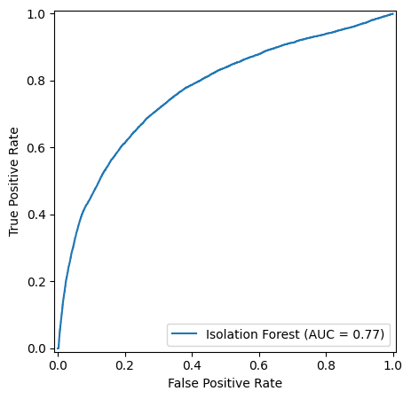

```python
# Para visualizar la curva ROC, calculamos los scores de anomalía para el conjunto de prueba
scores = -best_iso_for.score_samples(x_test)

# Calculamos la curva ROC y el AUC para el conjunto de prueba
fpr_iso_for, tpr_iso_for, thresholds = roc_curve(y_test, scores)
auc_iso_for = roc_auc_score(y_test, scores)

# Definimos el tamaño de la figura para la curva ROC
fig, ax = plt.subplots(figsize=(5, 5))

# Visualizamos la curva ROC utilizando RocCurveDisplay
RocCurveDisplay(
    fpr=fpr_iso_for,
    tpr=tpr_iso_for,
    roc_auc=auc_iso_for,
    name="Isolation Forest"
).plot(ax=ax)
```

## Árbol de detección de fraude

Ahora vamos a comprobar si un método supervisado sencillo e interpretable, como es un árbol de decisión, puede ayudarnos a resolver este problema.

Entrena un árbol de decisión sobre los datos de train, haciendo uso tanto de las variables explicativas como de la variable objetivo. Trata de que el árbol sea sencillo, de forma que puedas generar una visualización interpretable del mismo. Mide también los resultados del árbol en AUC sobre el conjunto de test. ¿Obtienes mejoras sobre el modelo no supervisado?

```python
# Creamos el modelo de clasificación
tree = DecisionTreeClassifier(
    random_state=42,
    class_weight='balanced'
)
```

```python
# Definimos el espacio de hiperparámetros para RandomizedSearchCV
param_grid = {
    "max_depth": [3, 5],
    "min_samples_leaf": [300,600,1000],
    'criterion': ['gini','entropy'],
    "max_features": [None, "sqrt", "log2"],
}

# Utilizamos RandomizedSearchCV para buscar los mejores hiperparámetros
# Sin necesidad de entrenar el modelo completo en cada iteración, lo que ahorra tiempo
grid  = RandomizedSearchCV(
    estimator=tree,
    param_distributions=param_grid,
    n_iter=20,   # Iteramos sobre 20 combinaciones aleatorias de hiperparámetros
    scoring='roc_auc',
    cv=3,       # Validación cruzada con 3 folds para acelerar el proceso
    n_jobs=-1,
    verbose=2,
    random_state=42
)

# Entrenamos el modelo con RandomizedSearchCV
grid.fit(x_train, y_train)

print('Mejores parametros:', grid.best_params_)

# Evaluamos el mejor modelo encontrado en el conjunto de prueba
best_model = grid.best_estimator_
y_proba_train = best_model.predict_proba(x_train)[:, 1]
y_proba_test = best_model.predict_proba(x_test)[:, 1]

# Imprimimos el número de hojas del árbol para entender su complejidad
print('Numero de hojas:', best_model.get_n_leaves())

# Calculamos el AUC-ROC en el conjunto de prueba
print('AUC en Train:', roc_auc_score(y_train, y_proba_train))
print('AUC en Test:', roc_auc_score(y_test, y_proba_test))
```

```
Fitting 3 folds for each of 20 candidates, totalling 60 fits
Mejores parametros: {'min_samples_leaf': 300, 'max_features': None, 'max_depth': 5, 'criterion': 'gini'}
Numero de hojas: 21
AUC en Train: 0.826974366
AUC en Test: 0.827977473
```

Ya que encontramos el mejor árbol con random search, ahora haremos post-prunning a ese árbol para asi tener un árbol mas interpretable.

Tenemos 21 hojas buscaremos algún número cercano a 10 para que sea más interpretable.

```python
# Generamos los pesos de las muestras para el conjunto de entrenamiento utilizando la función compute_sample_weight
weights = compute_sample_weight(class_weight='balanced', y=y_train)

# Utilizamos el método cost_complexity_pruning_path para obtener los valores de ccp_alpha para el mejor modelo encontrado
path = best_model.cost_complexity_pruning_path(x_train, y_train, sample_weight=weights)
ccp_alphas = path.ccp_alphas

print('Valores posibles para ccp_alphas:', len(ccp_alphas))
```

```
Valores posibles para ccp_alphas: 24
```

```python
alpha_evaluation = []
for i, alpha in enumerate(ccp_alphas):
    print(f'Evaluando alpha {i+1}/{len(ccp_alphas)}', end='\r')
    # Creamos el modelo de clasificación
    prunned_tree = DecisionTreeClassifier(
        random_state=42,
        class_weight='balanced',
        min_samples_leaf=300,
        max_features=None,
        max_depth=5,
        criterion='gini',
        ccp_alpha=alpha
    )

    # Entrenamos el modelo con los mejores hiperparámetros encontrados
    prunned_tree.fit(x_train, y_train)

    # Evaluamos el modelo podado en el conjunto de prueba
    y_proba_prunned = prunned_tree.predict_proba(x_test)[:, 1]
    auc_prunned = roc_auc_score(y_test, y_proba_prunned)
    n_leaves = prunned_tree.get_n_leaves()

    alpha_evaluation.append({'ccp_alpha': alpha,
                             'auc_test_prunned': auc_prunned,
                             'n_leaves': n_leaves,
                             'alpha_index': i}
                            )

# Transformamos la lista de diccionarios en un DataFrame para facilitar su análisis
alpha_evaluation = pd.DataFrame(alpha_evaluation)

# Revisamos los resultados de la evaluación de los diferentes valores de ccp_alpha
alpha_evaluation.sort_values(by=['auc_test_prunned','n_leaves'], ascending=[False,True])
```

```
Evaluando alpha 24/24
```

|  | ccp_alpha | auc_test_prunned | n_leaves | alpha_index |
| --- | --- | --- | --- | --- |
| 0 | 0.000000 | 0.827977 | 21 | 0 |
| 1 | 0.000004 | 0.827977 | 21 | 1 |
| 2 | 0.000014 | 0.827937 | 20 | 2 |
| 3 | 0.000058 | 0.827762 | 19 | 3 |
| 4 | 0.000158 | 0.827762 | 19 | 4 |
| 5 | 0.000177 | 0.827762 | 19 | 5 |
| 7 | 0.000266 | 0.827599 | 17 | 7 |
| 8 | 0.000269 | 0.827599 | 17 | 8 |
| 9 | 0.000271 | 0.827599 | 17 | 9 |
| 6 | 0.000198 | 0.827591 | 18 | 6 |
| 10 | 0.000423 | 0.827234 | 16 | 10 |
| 11 | 0.000423 | 0.827234 | 16 | 11 |
| 16 | 0.000744 | 0.827233 | 14 | 16 |
| 17 | 0.000931 | 0.827233 | 14 | 17 |
| 18 | 0.001354 | 0.827233 | 14 | 18 |
| 12 | 0.000467 | 0.827231 | 15 | 12 |
| 13 | 0.000532 | 0.827231 | 15 | 13 |
| 14 | 0.000547 | 0.827231 | 15 | 14 |
| 15 | 0.000639 | 0.827231 | 15 | 15 |
| 19 | 0.004219 | 0.810102 | 6 | 19 |
| 20 | 0.004534 | 0.810102 | 6 | 20 |
| 21 | 0.005904 | 0.810102 | 6 | 21 |
| 22 | 0.007755 | 0.810102 | 6 | 22 |
| 23 | 0.027862 | 0.713839 | 3 | 23 |

Viendo los resultados nos quedaremos con el arbol con alpha = 0.0007441487233403356

- Tiene 14 hojas, que ayuda con la interpretabilidad.
- AUC en test de 0.827

```python
# Seleccionamos el mejor modelo podado basado en el mejor AUC en test y menor número de hojas
best_prunned_clas_tree = DecisionTreeClassifier(
    random_state=42,
    class_weight='balanced',
    min_samples_leaf=300,
    max_features=None,
    max_depth=5,
    criterion='gini',
    ccp_alpha=ccp_alphas[16]
)

# Entrenamos el modelo
best_prunned_clas_tree.fit(x_train, y_train)

# Obtenemos las probabilidades de predicción para el conjunto de entrenamiento y prueba
y_train_proba = best_prunned_clas_tree.predict_proba(x_train)[:, 1]
y_test_proba = best_prunned_clas_tree.predict_proba(x_test)[:, 1]

# AUC
train_auc = roc_auc_score(y_train, y_train_proba)
test_auc = roc_auc_score(y_test, y_test_proba)

print('AUC del mejor árbol podado en Train:', train_auc)
print('AUC del mejor árbol podado en Test:', test_auc)
```

```
AUC del mejor árbol podado en Train: 0.824841264
AUC del mejor árbol podado en Test: 0.827233462
```

Visualizamos el árbol

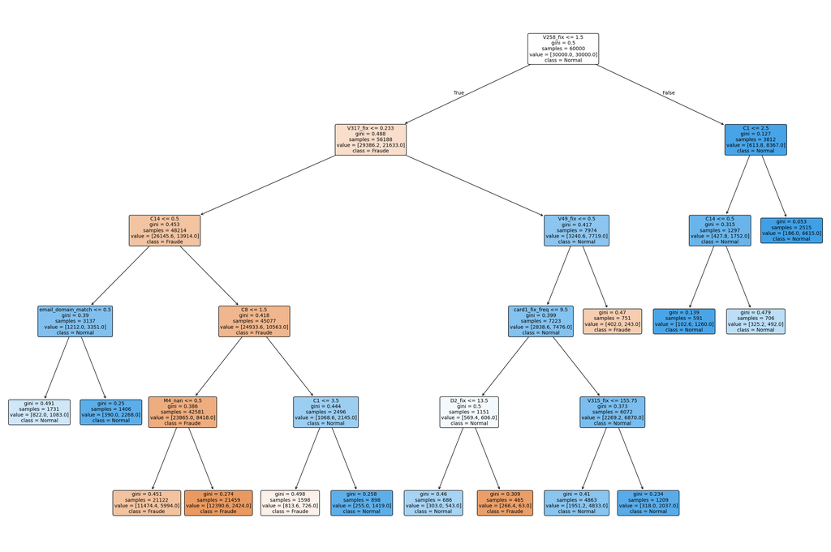

```python
# Configuramos el tamaño de la figura para visualizar el árbol de decisión
plt.figure(figsize=(30, 20))

# Visualizamos el árbol de decisión utilizando plot_tree
plot_tree(
    best_prunned_clas_tree,
    feature_names=x_train.columns,
    class_names=['Fraude','Normal'],
    filled=True,
    rounded=True,
    fontsize=10
)

plt.show()
```

Importancia de variables

```python
importances = best_prunned_clas_tree.feature_importances_

feature_importance = pd.DataFrame(importances, index=x_train.columns, columns=['Importancia de variables'])
feature_importance = feature_importance.sort_values(by='Importancia de variables', ascending=False)
# Filtramos solo las variables con importancia mayor a 0
feature_importance = feature_importance[feature_importance['Importancia de variables'] > 0].copy()
# Calculamos la suma acumulada de la importancia de las variables
# para entender su contribución relativa al modelo
feature_importance['Suma acumulada'] = feature_importance['Importancia de variables'].cumsum()
feature_importance
```

|  | Importancia de variables | Suma acumulada |
| --- | --- | --- |
| V258_fix | 0.385718 | 0.385718 |
| V317_fix | 0.214943 | 0.600661 |
| C14 | 0.161632 | 0.762293 |
| C8 | 0.094762 | 0.857055 |
| M4_nan | 0.050631 | 0.907686 |
| C1 | 0.031468 | 0.939154 |
| email_domain_match | 0.017638 | 0.956792 |
| V49_fix | 0.014414 | 0.971206 |
| card1_fix_freq | 0.011382 | 0.982588 |
| D2_fix | 0.009435 | 0.992023 |
| V315_fix | 0.007977 | 1.000000 |

Visualizamos la curva ROC para Test

```
<sklearn.metrics._plot.roc_curve.RocCurveDisplay at 0x1ef36ab7360>
```

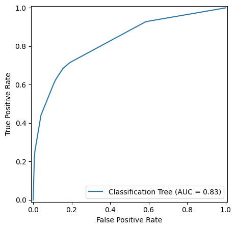

```python
# Calculamos la curva ROC y el AUC para el conjunto de prueba
y_proba = best_prunned_clas_tree.predict_proba(x_test)[:, 1]
fpr_clas_tree, tpr_clas_tree, thresholds = roc_curve(y_test, y_proba)
auc_clas_tree = roc_auc_score(y_test, y_proba)

# Definimos el tamaño de la figura para la curva ROC
fig, ax = plt.subplots(figsize=(5, 5))

# Visualizamos la curva ROC utilizando RocCurveDisplay
RocCurveDisplay(
    fpr=fpr_clas_tree,
    tpr=tpr_clas_tree,
    roc_auc=auc_clas_tree,
    name='Classification Tree'
).plot(ax=ax)
```

El árbol de decisión claramente es mejor que el modelo anterior (isolation forest)

- La diferencia entre el mejor AUC entre train (~0.824) y test (~0.827) es minima (~0.003), lo cual indica que el modelo no sobre ajusta.
- El top 5 de variables concentra alrededor del 90% de la importancia de variables.
- El modelo utiliza una mezcla de todos los segmentos, ya que es una base de datos anonimizada, no se puede interpretar mucho.
  - Utiliza las variables sel segmento V en primer lugar para hacer los primeros cortes.
  - Luego los contadores (segmento C) toman importancia.
  - Utiliza el indicador cuando los dominios del comprador y de quien recibe la compra son diferentes, lo cual tiene sentido de negocio.

## Modelos supervisados de ensemble

Vamos a comprobar cómo es posible mejorar los resultados de detección usando métodos de ensemble. Entrena **al menos 5 de los métodos de ensemble vistos en clase**, y mide sus resultados de AUC en el test. **Debes justificar todas las decisiones de diseño que tomes a la hora de elegir estos modelos, así como sus parámetros**.

Algunas sugerencias de modelos disponibles en scikit-learn que puedes utilizar:

- Random Forest
- Extra Trees
- AdaBoost
- Gradient Boosting
- Histogram-based Gradient Boosting
- Bagging
- Voting
- Stacking

No olvides que para medir correctamente el AUC, debes suministrar a esta métrica las **probabilidades de clase fraude** predichas por el modelo, las cuales puedes obtener mediante el método *predict_proba*.

Si has entrenado los modelos correctamente, tu mejor resultado debería ser de al menos un **92% de AUC** en test.

Adicionalmente, se valorará:

- Utilizar más técnicas de ensembles, además de las 5 mínimas requeridas.
- Mejorar el AUC en test de tu modelo lo máximo posible.
- Utilizar [CatBoost](https://catboost.ai/), [LightGBM](https://lightgbm.readthedocs.io/en/latest/) o [AutoGluon](https://auto.gluon.ai/), otras librerías de ensemble muy efectivas. Nótese que deberás instalar estas librerías en el entorno.

### Random Forest

- Mantendremos el criterio de impureza del mejor árbol clasificador (gini).
- Lo mismo para el mínimo de observaciones por hoja (300).
- Experimentaremos en un grid search con el numero de arboles para el bosque.
- La profundidad maxima para cada arbol.
- La cantidad maxima de variables que puede tomar en cada corte.

```python
# Creamos el modelo de clasificación Random Forest
rf_classifier = RandomForestClassifier(random_state=42,
                                       n_jobs=-1,
                                       class_weight='balanced',
                                       bootstrap=True,
                                       criterion='gini',
                                       min_samples_leaf=300
                                    )

# Definimos el espacio de hiperparámetros para GridSearchCV
param_grid = {
    'n_estimators': [300, 500,1000],
    'max_depth': [5,8],
    'max_features': ['sqrt','log2'],
}
```

```python
# Utilizamos GridSearchCV para buscar los mejores hiperparámetros
rf_grid_search  = GridSearchCV(
                        estimator=rf_classifier,
                        param_grid=param_grid,
                        scoring='roc_auc',
                        cv=2,       # Validación cruzada con 2 folds para acelerar el proceso
                        n_jobs=-1,
                        verbose=2,
                    )

# Entrenamos el modelo con GridSearchCV
rf_grid_search.fit(x_train, y_train)

print('Mejores parametros:', rf_grid_search.best_params_)

# Evaluamos el mejor modelo encontrado en el conjunto de prueba
best_rf = rf_grid_search.best_estimator_
y_proba_train = best_rf.predict_proba(x_train)[:, 1]
y_proba_test = best_rf.predict_proba(x_test)[:, 1]

# Calculamos el AUC-ROC en el conjunto de prueba
print('AUC en Train:', roc_auc_score(y_train, y_proba_train))
print('AUC en Test:', roc_auc_score(y_test, y_proba_test))
```

```
Fitting 2 folds for each of 12 candidates, totalling 24 fits
Mejores parametros: {'max_depth': 8, 'max_features': 'sqrt', 'n_estimators': 1000}
AUC en Train: 0.859605408
AUC en Test: 0.857642934
```

Visualizamos la curva ROC para Test

```
<sklearn.metrics._plot.roc_curve.RocCurveDisplay at 0x1ef5bb49fd0>
```

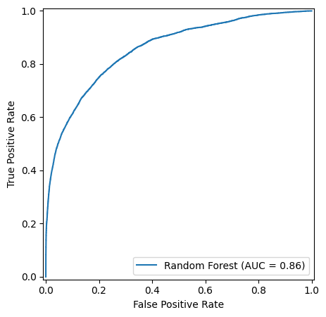

```python
# Calculamos la curva ROC y el AUC para el conjunto de prueba
y_proba_test = best_rf.predict_proba(x_test)[:, 1]
fpr_rf_tree, tpr_rf_tree, thresholds = roc_curve(y_test, y_proba_test)
auc_rf_tree = roc_auc_score(y_test, y_proba_test)

# Definimos el tamaño de la figura para la curva ROC
fig, ax = plt.subplots(figsize=(5, 5))

# Visualizamos la curva ROC utilizando RocCurveDisplay
RocCurveDisplay(
    fpr=fpr_rf_tree,
    tpr=tpr_rf_tree,
    roc_auc=auc_rf_tree,
    name='Random Forest'
).plot(ax=ax)
```

### Extra Tree

```python
# Creamos el modelo de clasificación Extra Trees Classifier
et = ExtraTreesClassifier(
    class_weight="balanced",
    random_state=42,
    n_jobs=-1,
    criterion='gini',
    n_estimators=500,
    max_features='sqrt'
)

# Definimos el espacio de hiperparámetros para GridSearchCV
# daremos mayor libertad al modelo para que pueda encontrar
# la mejor profundidad y número de hojas
param_grid = {
    'max_depth': [8,10,15],
    'min_samples_leaf': [10,25,50]
}
```

```python
# Utilizamos GridSearchCV para buscar los mejores hiperparámetros
et_grid_search  = GridSearchCV(
                        estimator=et,
                        param_grid=param_grid,
                        scoring='roc_auc',
                        cv=2,       # Validación cruzada con 2 folds para acelerar el proceso
                        n_jobs=-1,
                        verbose=2,
                    )

# Entrenamos el modelo con GridSearchCV
et_grid_search.fit(x_train, y_train)

# Evaluamos el mejor modelo encontrado en el conjunto de prueba
best_et = et_grid_search.best_estimator_

print('Mejores parametros:', et_grid_search.best_params_)

y_proba_train = best_et.predict_proba(x_train)[:, 1]
y_proba_test = best_et.predict_proba(x_test)[:, 1]

# Calculamos el AUC-ROC en el conjunto de prueba
print('AUC en Train:', roc_auc_score(y_train, y_proba_train))
print('AUC en Test:', roc_auc_score(y_test, y_proba_test))
```

```
Fitting 2 folds for each of 9 candidates, totalling 18 fits
Mejores parametros: {'max_depth': 15, 'min_samples_leaf': 10}
AUC en Train: 0.8930778279999999
AUC en Test: 0.874253117
```

Visualizamos la curva ROC para Test

```
<sklearn.metrics._plot.roc_curve.RocCurveDisplay at 0x1ef689bc160>
```

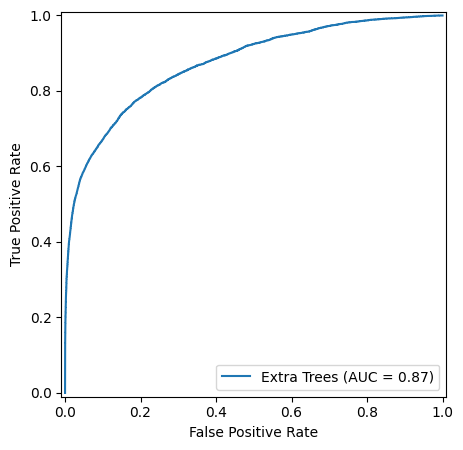

```python
# Calculamos la curva ROC y el AUC para el conjunto de prueba
y_proba_test = best_et.predict_proba(x_test)[:, 1]
fpr_et_tree, tpr_et_tree, thresholds = roc_curve(y_test, y_proba_test)
auc_et_tree = roc_auc_score(y_test, y_proba_test)

# Definimos el tamaño de la figura para la curva ROC
fig, ax = plt.subplots(figsize=(5, 5))

# Visualizamos la curva ROC utilizando RocCurveDisplay
RocCurveDisplay(
    fpr=fpr_et_tree,
    tpr=tpr_et_tree,
    roc_auc=auc_et_tree,
    name='Extra Trees'
).plot(ax=ax)
```

Obtenemos un AUC en test ligeramente superior a random forest. La diferencia entre Train (~0.893) y Test (~0.874) es minima (~0.019), por lo que no hay un sobre ajuste.

### Ada Boost

- Utilizaremos como modelo base un árbol clasificador con un máximo de profundidad de tamaño 3.
- Mantendremos el criterio de impureza utilizado anteriormente (gini).

```python
# Creamos el modelo de Ada Boost
ada_model = AdaBoostClassifier(
    estimator=DecisionTreeClassifier(random_state=42,
                                     max_depth=3,
                                     criterion='gini'),
    random_state=42
)

# Definimos el espacio de hiperparámetros para GridSearchCV
# daremos mayor libertad al modelo para que pueda encontrar
# la mejor profundidad y número de hojas
param_grid = {
    'n_estimators': [50,100],
    'learning_rate': [0.1, 1]
}
```

```python
# Utilizamos GridSearchCV para buscar los mejores hiperparámetros
ada_grid_search  = GridSearchCV(
                        estimator=ada_model,
                        param_grid=param_grid,
                        scoring='roc_auc',
                        cv=2,       # Validación cruzada con 2 folds para acelerar el proceso
                        n_jobs=-1,
                        verbose=2,
                    )
# Entrenamos el modelo de AdaBoost con el conjunto de entrenamiento
ada_grid_search.fit(x_train, y_train)

# Evaluamos el mejor modelo encontrado en el conjunto de prueba
best_ada = ada_grid_search.best_estimator_
print('Mejores parametros:', ada_grid_search.best_params_)

ada_probs_train = ada_grid_search.predict_proba(x_train)[:, 1]
ada_probs_test = ada_grid_search.predict_proba(x_test)[:, 1]
# Calculamos el AUC-ROC en el conjunto de entrenamiento y prueba
ada_train_auc = roc_auc_score(y_train, ada_probs_train)
ada_test_auc = roc_auc_score(y_test, ada_probs_test)

print('AUC de AdaBoost en Train:', ada_train_auc)
print('AUC de AdaBoost en Test:', ada_test_auc)
```

```
Fitting 2 folds for each of 4 candidates, totalling 8 fits
Mejores parametros: {'learning_rate': 1, 'n_estimators': 100}
AUC de AdaBoost en Train: 0.8937336709999999
AUC de AdaBoost en Test: 0.883739992
```

Visualizamos la curva ROC para Test

```
<sklearn.metrics._plot.roc_curve.RocCurveDisplay at 0x1ef689bc270>
```

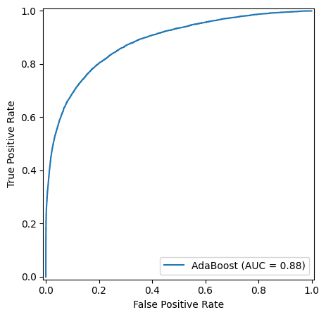

```python
# Calculamos la curva ROC y el AUC para el conjunto de prueba
y_proba_test = best_ada.predict_proba(x_test)[:, 1]
fpr_ada_tree, tpr_ada_tree, thresholds = roc_curve(y_test, y_proba_test)
auc_ada_tree = roc_auc_score(y_test, y_proba_test)

# Definimos el tamaño de la figura para la curva ROC
fig, ax = plt.subplots(figsize=(5, 5))

# Visualizamos la curva ROC utilizando RocCurveDisplay
RocCurveDisplay(
    fpr=fpr_ada_tree,
    tpr=tpr_ada_tree,
    roc_auc=auc_ada_tree,
    name='AdaBoost'
).plot(ax=ax)
```

Obtenemos un AUC en test ligeramente superior a Extra Tree. La diferencia entre Train (~0.893) y Test (~0.883) es minima (~0.01), por lo que no hay un sobre ajuste.

### Gradient Boosting

Para determinar el mejor modelo con Gradient Boosting, utilizaremos una búsqueda con GridSearch.

```python
gb_model = GradientBoostingClassifier(random_state=42)

param_grid = {
    'n_estimators': [100, 200],
    'learning_rate': [0.05, 0.1],
    'max_depth': [3, 5],
    'min_samples_leaf': [10, 20],
    'subsample': [0.8, 1.0]
}

gb_grid_search = GridSearchCV(
    gb_model,
    param_grid,
    scoring='roc_auc',
    cv=2,
    n_jobs=-1,
    verbose=2
)

gb_grid_search.fit(x_train, y_train)
print('Mejores parametros:', gb_grid_search.best_params_)

best_gb = gb_grid_search.best_estimator_

gb_probs_train = best_gb.predict_proba(x_train)[:, 1]
gb_probs_test = best_gb.predict_proba(x_test)[:, 1]

gb_train_auc = roc_auc_score(y_train, gb_probs_train)
gb_test_auc = roc_auc_score(y_test, gb_probs_test)

print('AUC de Gradient Boosting con GridSearch en Train:', gb_train_auc)
print('AUC de Gradient Boosting con GridSearch en Test:', gb_test_auc)
```

```
Fitting 2 folds for each of 32 candidates, totalling 64 fits
Mejores parametros: {'learning_rate': 0.1, 'max_depth': 5, 'min_samples_leaf': 10, 'n_estimators': 200, 'subsample': 1.0}
AUC de Gradient Boosting con GridSearch en Train: 0.940807533
AUC de Gradient Boosting con GridSearch en Test: 0.9203748999999999
```

Visualizamos la curva ROC para Test

```
<sklearn.metrics._plot.roc_curve.RocCurveDisplay at 0x1ef686cac50>
```

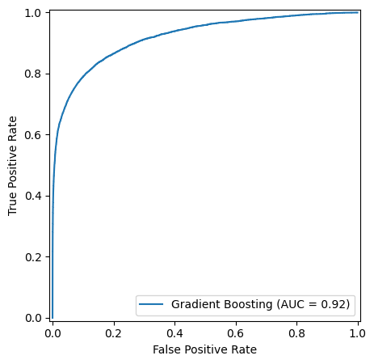

```python
# Calculamos la curva ROC y el AUC para el conjunto de prueba
y_proba_test = best_gb.predict_proba(x_test)[:, 1]
fpr_gb_tree, tpr_gb_tree, thresholds = roc_curve(y_test, y_proba_test)
auc_gb_tree = roc_auc_score(y_test, y_proba_test)

# Definimos el tamaño de la figura para la curva ROC
fig, ax = plt.subplots(figsize=(5, 5))

# Visualizamos la curva ROC utilizando RocCurveDisplay
RocCurveDisplay(
    fpr=fpr_gb_tree,
    tpr=tpr_gb_tree,
    roc_auc=auc_gb_tree,
    name='Gradient Boosting'
).plot(ax=ax)
```

Obtenemos un AUC en test ligeramente superior a Ada Boost. La diferencia entre Train (~0.940) y Test (~0.920) es minima (~0.02), por lo que no hay un sobre ajuste.

### Histogram-based Gradient Boosting

Para determinar el mejor modelo con Histogram-based Gradient Boosting, utilizaremos una búsqueda con GridSearch.

```python
hgb_model = HistGradientBoostingClassifier(random_state=42,
                                           early_stopping=True)

param_grid = {
    'max_iter': [100, 200],
    'learning_rate': [0.05, 0.1],
    'max_depth': [5, 10],
    'min_samples_leaf': [10, 20],
    'l2_regularization': [0.0, 0.1]
}

grid_search = GridSearchCV(
    hgb_model,
    param_grid,
    scoring='roc_auc',
    cv=2,
    n_jobs=-1,
    verbose=2
)

grid_search.fit(x_train, y_train)
print('Mejores parametros:', grid_search.best_params_)

best_hgb = grid_search.best_estimator_

hgb_probs_train = best_hgb.predict_proba(x_train)[:, 1]
hgb_probs_test = best_hgb.predict_proba(x_test)[:, 1]
hgb_train_auc = roc_auc_score(y_train, hgb_probs_train)
hgb_test_auc = roc_auc_score(y_test, hgb_probs_test)
print('AUC de HistGradientBoosting con GridSearch en Train:', hgb_train_auc)
print('AUC de HistGradientBoosting con GridSearch en Test:', hgb_test_auc)
```

```
Fitting 2 folds for each of 32 candidates, totalling 64 fits
Mejores parametros: {'l2_regularization': 0.1, 'learning_rate': 0.1, 'max_depth': 10, 'max_iter': 200, 'min_samples_leaf': 20}
AUC de HistGradientBoosting con GridSearch en Train: 0.962846452
AUC de HistGradientBoosting con GridSearch en Test: 0.933795122
```

Visualizamos la curva ROC para Test

```
<sklearn.metrics._plot.roc_curve.RocCurveDisplay at 0x1ef686cae50>
```

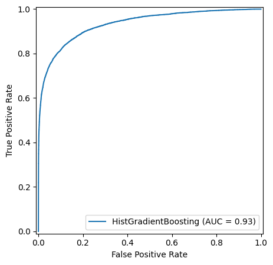

```python
# Calculamos la curva ROC y el AUC para el conjunto de prueba
y_proba_test = best_hgb.predict_proba(x_test)[:, 1]
fpr_hgb_tree, tpr_hgb_tree, thresholds = roc_curve(y_test, y_proba_test)
auc_hgb_tree = roc_auc_score(y_test, y_proba_test)

# Definimos el tamaño de la figura para la curva ROC
fig, ax = plt.subplots(figsize=(5, 5))

# Visualizamos la curva ROC utilizando RocCurveDisplay
RocCurveDisplay(
    fpr=fpr_hgb_tree,
    tpr=tpr_hgb_tree,
    roc_auc=auc_hgb_tree,
    name='HistGradientBoosting'
).plot(ax=ax)
```

Obtenemos un AUC en test ligeramente superior a Gradient Boosting. La diferencia entre Train (~0.962) y Test (~0.933) es minima (~0.029), por lo que no hay un sobre ajuste.

- l2_regularization (0.1): Penaliza la complejidad previniendo el sobre ajuste, y ayudando a la generalización.
- learning_rate (0.1): Controla cuanto contribuye cada árbol al modelo, balanceando velocidad de aprendizaje y estabilidad.
- max_depth (10): Se elige este nivel máximo de profundidad para cada árbol ya que permite capturar complejidad sin sobre ajustar.
- max_iter (200): Define el numero de iteraciones, para converger. min_samples_leaf (20): Mínimo de observaciones por hoja para prevenir el sobre ajuste.

### CatBoost

Dividimos Train en Train y Evaluation, en una proporción 80/20

Ya que CatBoost necesita un set de evaluación a medida que va iterando va midiendo el rendimiento con el set de evaluación, y cuando este ya no mejora deja de iterar.

```python
x_catb_train, x_catb_eval, y_catb_train, y_catb_eval = train_test_split(x_train,
                                                                       y_train,
                                                                       test_size=0.2,
                                                                       random_state=42
                                                                    )
```

```python
cb_class = CatBoostClassifier(
    iterations=2000,
    learning_rate=0.03,
    depth=7,
    loss_function='Logloss',
    eval_metric='AUC',
    auto_class_weights='Balanced',
    early_stopping_rounds=50,
    l2_leaf_reg=3,
    verbose=100
)

cb_class.fit(x_catb_train, y_catb_train, eval_set=(x_catb_eval, y_catb_eval))

catb_probs_train = cb_class.predict_proba(x_catb_train)[:, 1]
catb_probs_test = cb_class.predict_proba(x_test)[:, 1]

catb_train_auc = roc_auc_score(y_catb_train, catb_probs_train)
catb_test_auc = roc_auc_score(y_test, catb_probs_test)

print('AUC de CatBoost en Train:', catb_train_auc)
print('AUC de CatBoost en Test:', catb_test_auc)
```

```
0:	test: 0.8228270	best: 0.8228270 (0)	total: 62.3ms	remaining: 2m 4s
100:	test: 0.8821284	best: 0.8821284 (100)	total: 6.13s	remaining: 1m 55s
200:	test: 0.8951980	best: 0.8951980 (200)	total: 14.5s	remaining: 2m 10s
300:	test: 0.9026390	best: 0.9026390 (300)	total: 22.4s	remaining: 2m 6s
400:	test: 0.9105219	best: 0.9105219 (400)	total: 31.4s	remaining: 2m 5s
500:	test: 0.9180278	best: 0.9180278 (500)	total: 44.1s	remaining: 2m 11s
600:	test: 0.9228901	best: 0.9228901 (600)	total: 53.4s	remaining: 2m 4s
700:	test: 0.9263012	best: 0.9263012 (700)	total: 1m 1s	remaining: 1m 53s
800:	test: 0.9291537	best: 0.9291537 (800)	total: 1m 9s	remaining: 1m 43s
900:	test: 0.9307189	best: 0.9307189 (900)	total: 1m 17s	remaining: 1m 34s
1000:	test: 0.9328288	best: 0.9328288 (1000)	total: 1m 24s	remaining: 1m 24s
1100:	test: 0.9340752	best: 0.9340752 (1100)	total: 1m 31s	remaining: 1m 14s
1200:	test: 0.9357099	best: 0.9357099 (1200)	total: 1m 38s	remaining: 1m 5s
1300:	test: 0.9368393	best: 0.9368433 (1299)	total: 1m 43s	remaining: 55.8s
1400:	test: 0.9377083	best: 0.9377083 (1400)	total: 1m 49s	remaining: 47s
1500:	test: 0.9386809	best: 0.9386809 (1500)	total: 1m 55s	remaining: 38.5s
1600:	test: 0.9396166	best: 0.9396172 (1597)	total: 2m 2s	remaining: 30.5s
1700:	test: 0.9404457	best: 0.9404457 (1700)	total: 2m 9s	remaining: 22.8s
1800:	test: 0.9412115	best: 0.9412115 (1800)	total: 2m 17s	remaining: 15.2s
1900:	test: 0.9418588	best: 0.9418588 (1900)	total: 2m 25s	remaining: 7.59s
1999:	test: 0.9423885	best: 0.9423885 (1999)	total: 2m 33s	remaining: 0us

bestTest = 0.9423884601
bestIteration = 1999

AUC de CatBoost en Train: 0.985038861930122
AUC de CatBoost en Test: 0.9418024829999999
```

Visualizamos la curva ROC para Test

```
<sklearn.metrics._plot.roc_curve.RocCurveDisplay at 0x1ef5c01f5c0>
```

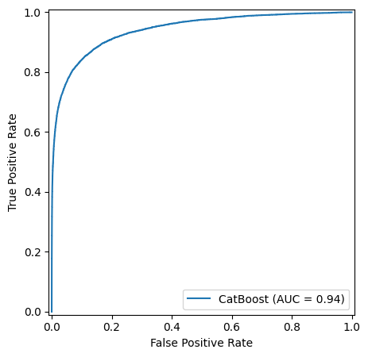

```python
# Calculamos la curva ROC y el AUC para el conjunto de prueba
y_proba_test = cb_class.predict_proba(x_test)[:, 1]
fpr_cb_tree, tpr_cb_tree, thresholds = roc_curve(y_test, y_proba_test)
auc_cb_tree = roc_auc_score(y_test, y_proba_test)

# Definimos el tamaño de la figura para la curva ROC
fig, ax = plt.subplots(figsize=(5, 5))

# Visualizamos la curva ROC utilizando RocCurveDisplay
RocCurveDisplay(
    fpr=fpr_cb_tree,
    tpr=tpr_cb_tree,
    roc_auc=auc_cb_tree,
    name='CatBoost'
).plot(ax=ax)
```

Obtenemos un AUC en test ligeramente superior a Histogram-based Gradient Boosting. La diferencia entre Train (~0.985) y Test (~0.941) es de (~0.044), lo que podría hacer pensar de que puede haber un sobre ajuste. Pero el modelo al trabajar sobre los errores del modelo anterior en el ensemble tiende a tener un AUC en train alto en el conjunto de entrenamiento, el alto rendimiento se mantiene en el conjunto de prueba, asi que la diferencia no es alarmante.

- Se utilizaron 2000 iteraciones para permitir que el modelo tenga suficiente capacidad de aprendizaje, confiando en el mecanismo de early stopping para evitar el sobreentrenamiento.
- Se definió una tasa de aprendizaje de 0.03, lo que permite un aprendizaje más lento pero más estable, mejorando la capacidad de generalización del modelo.
- Se eligió una profundidad de árbol de 7, lo que proporciona un equilibrio entre complejidad y capacidad de capturar patrones relevantes, reduciendo el riesgo de sobreajuste en comparación con profundidades mayores.
- Se utilizó la función de pérdida Logloss, adecuada para problemas de clasificación binaria, ya que penaliza de forma efectiva las predicciones incorrectas probabilísticas.
- Se incluyó early_stopping_rounds=50 para detener el entrenamiento automáticamente cuando el rendimiento en el conjunto de validación deja de mejorar, reduciendo el riesgo de sobreajuste y optimizando el tiempo de entrenamiento.
- Se aplicó una regularización L2 (l2_leaf_reg=3) para controlar la complejidad del modelo, evitando valores extremos en las hojas de los árboles y mejorando la generalización.

### Voting, con pesos donde el peso es el AUC del modelo en Train.

Ya que todos los modelos entrenados tienen el método (.predict_proba) a excepción del isolation forest, juntaremos a todo y haremos una votación del tipo (soft) utilizando las probabilidades y evaluaremos el rendimiento.

```python
# Creamos un ensemble de votación utilizando todos los modelos entrenados
vote_models = [
    best_prunned_clas_tree,
    best_rf,
    best_et,
    best_ada,
    best_gb,
    best_hgb,
    cb_class
]

# Obtenemos los pesos para cada modelo en el ensemble de votación
# basados en su AUC en el conjunto de entrenamiento
# para evitar el data leakage, ya que el AUC en test se usará para evaluar el ensemble de votación
model_weights = [
    roc_auc_score(y_train, best_prunned_clas_tree.predict_proba(x_train)[:, 1]),  # AUC del árbol de decisión podado
    roc_auc_score(y_train, best_rf.predict_proba(x_train)[:, 1]),  # AUC del Random Forest
    roc_auc_score(y_train, best_et.predict_proba(x_train)[:, 1]),  # AUC del Extra Trees
    roc_auc_score(y_train, best_ada.predict_proba(x_train)[:, 1]),  # AUC del AdaBoost
    roc_auc_score(y_train, best_gb.predict_proba(x_train)[:, 1]),  # AUC del Gradient Boosting
    roc_auc_score(y_train, best_hgb.predict_proba(x_train)[:, 1]),  # AUC del HistGradientBoosting
    roc_auc_score(y_train, cb_class.predict_proba(x_train)[:, 1])   # AUC del catBoost
]

# Obtenemos las probabilidades de predicción para cada modelo en el conjunto de entrenamiento y prueba
y_probs_voting_train = [model.predict_proba(x_train)[:, 1] for model in vote_models]
y_probs_voting_test = [model.predict_proba(x_test)[:, 1] for model in vote_models]

# Calculamos la probabilidad con el peso de cada modelo en el ensemble de votación
# para cada muestra en el conjunto de entrenamiento y prueba
y_probs_weighted_train = np.average(y_probs_voting_train, axis=0, weights=model_weights)
y_probs_weighted_test = np.average(y_probs_voting_test, axis=0, weights=model_weights)

# Calculamos el AUC-ROC del ensemble de votación en el conjunto de entrenamiento y prueba
voting_train_auc = roc_auc_score(y_train, y_probs_weighted_train)
voting_test_auc = roc_auc_score(y_test, y_probs_weighted_test)
print('AUC del Ensemble Voting en Train:', voting_train_auc)
print('AUC del Ensemble Voting en Test:', voting_test_auc)
```

```
AUC del Ensemble Voting en Train: 0.947332687
AUC del Ensemble Voting en Test: 0.92074644
```

Visualizamos la curva ROC para Test

```
<sklearn.metrics._plot.roc_curve.RocCurveDisplay at 0x1ef3698b890>
```

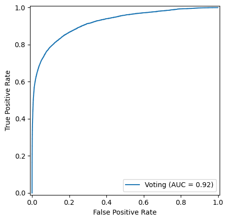

```python
# Calculamos la curva ROC y el AUC para el conjunto de prueba
fpr_vot_tree, tpr_vot_tree, thresholds = roc_curve(y_test, y_probs_weighted_test)
auc_vot_tree = roc_auc_score(y_test, y_probs_weighted_test)

# Definimos el tamaño de la figura para la curva ROC
fig, ax = plt.subplots(figsize=(5, 5))

# Visualizamos la curva ROC utilizando RocCurveDisplay
RocCurveDisplay(
    fpr=fpr_vot_tree,
    tpr=tpr_vot_tree,
    roc_auc=auc_vot_tree,
    name='Voting'
).plot(ax=ax)
```

## Visualización

Crea una visualización mostrando el rendimiento de todos tus modelos supervisados sobre el conjunto de test, junto con el modelo no supervisado. La visualización debe mostrar claramente cuál es el modelo con mayor AUC.

Armamos un dataframe con los AUC, de todos los modelos supervisados.

```python
auc_supervised_models = [auc_clas_tree,
                         auc_rf_tree,
                         auc_et_tree,
                         auc_ada_tree,
                         auc_gb_tree,
                         auc_hgb_tree,
                         auc_cb_tree,
                         auc_vot_tree
                        ]

model_names = ['Classification Tree',
               'Random Forest',
               'Extra Trees',
               'AdaBoost',
               'Gradient Boosting',
               'HistGradientBoosting',
               'CatBoost',
               'Voting Ensemble'
            ]

auc_df = pd.DataFrame({
    'Model': model_names,
    'AUC': auc_supervised_models
})

auc_df = auc_df.sort_values(by='AUC', ascending=False).reset_index(drop=True)

# Convertimos la columna 'Model' a tipo categórico para mantener el orden en la visualización
auc_df['Model'] = pd.Categorical(auc_df['Model'], categories=auc_df['Model'], ordered=True)
```

Graficamos

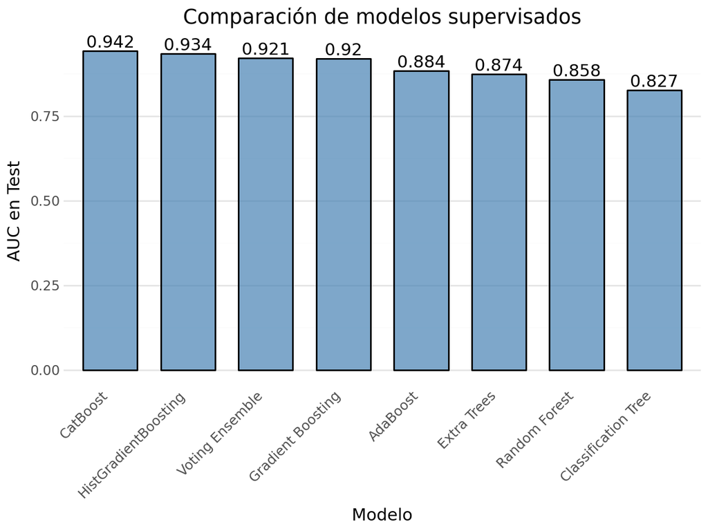

```python
(
    p9.ggplot(auc_df, p9.aes(x='Model', y='AUC'))
    + p9.geom_bar(stat='identity', fill='steelblue', color='black', width=0.7, alpha=0.7, size=0.6)
    + p9.geom_text(p9.aes(label='round(AUC, 3)'), va='bottom')
    + p9.theme_minimal()
    + p9.theme(axis_text_x=p9.element_text(rotation=45, ha='right'),
               panel_grid_major_x=p9.element_blank()
            )
    + p9.labs(
        title='Comparación de modelos supervisados',
        x='Modelo',
        y='AUC en Test'
    )
).show()
```

El modelo CatBoost obtuvo el mejor desempeño (AUC = 0.942), seguido de HistGradientBoosting, lo que indica que los métodos de boosting son los más efectivos para este problema, superando claramente a modelos como Random Forest y árboles de decisión.